[O’Hara on GitHub](https://github.com/oharac)

# Map species stressor intersections

Compiled on Tue Apr 14 13:58:33 2020 by ohara

```r
library(raster)
source('https://raw.githubusercontent.com/oharac/src/master/R/common.R')

source(here('common_fxns.R'))

dir_str_95cv <- file.path(dir_bd_anx, 'layers/stressors_10km_95cv')
dir_spp_maps <- file.path(dir_bd_anx, 'spp_rasts_mol_2020')
```

# 1 Summary

Here we will calculate, for each species, a map of impacted area for each of the stressors to which the species is sensitive; stressor ranges may change over time as well. These maps will be saved as a .csv of `cell_id` and `str_year`. The stressor values are dropped here to save on resulting file size; simply mapping present or not present. Stressor values can be recovered from the stressor maps themselves.

Maps (.csvs) will be saved for each species in a folder for each stressor. For non-impacted species, a place-holder will be saved, perhaps with `cell_id = NA`.

The matrix method would work well for calculating cumulative impact, but we will skip that for now to enable more resolution at the species and stressor level.

## 1.1 Methods summary

Briefly, the method will loop over each stressor and species; if the species has a non-zero sensitivity to the stressor, the overlap of species range and stressor range will be mapped. If the species is not sensitive, it will still be logged with a placeholder, for process checking…

Note that the intersection cells include only those cells where the species AND stressor are both present in a given year for a given stressor. Range cells outside the stressor area are dropped and are assumed to be unimpacted (refugia); stressor cells outside the range area are dropped and assumed to have no impact on this species.

# 2 Methods

## 2.1 Get the species sensitivities

The species sensitivity dataframe is created in script 1: `1_calc_spp_stressor_sensitivities.Rmd`. Load this and use it to identify included species and stressors; load the maps file to determine which of these species have range maps as well. Note, the sensitivity file includes non-threatened species, so these will be included in the overall set of intersection maps. Make sure to exclude non-threatened species when aggregating species maps to taxon level!

## 2.2 Loop over stressors

Let’s create a function to take a stressor name and use that to pull all the stressor layers (all years) into a raster stack. Let’s also create a function to turn the raster stack into a dataframe of cell IDs and filter to non-NA cells.

Using this function, loop through each of the included stressors, build the stack, convert to df for easier handling, and then loop over all species to create a map of cell ID and year for all stressor occurrences on the species range. The stressor name will be included in the filename, so no need to include a “stressor” column here… this should save significantly on file size.

# 3 Check results

Make sure all spp are represented in all stressors (even if an empty csv as a placeholder). Using file size as a proxy for the map size, we can get an impression of how widely distributed the stressor/species interactions are.

| str | n_spp |
| --- | --- |
| art_fish | 3864 |
| dem_dest | 3864 |
| dem_nondest_hb | 3864 |
| dem_nondest_lb | 3864 |
| direct_human | 3864 |
| light | 3864 |
| nutrient | 3864 |
| oa | 3864 |
| organic | 3864 |
| pel_hb | 3864 |
| pel_lb | 3864 |
| shipping | 3864 |
| slr | 3864 |
| sst | 3864 |

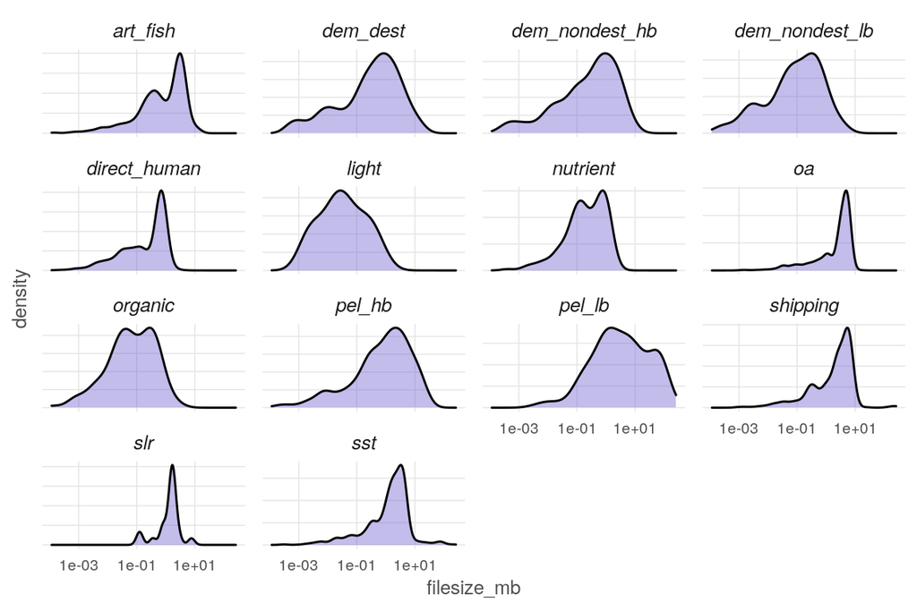